# A New Approach to Linear Filtering and Prediction Problems

Теперь давайте посмотрим, как повлияет неправильный выбор для $h$.

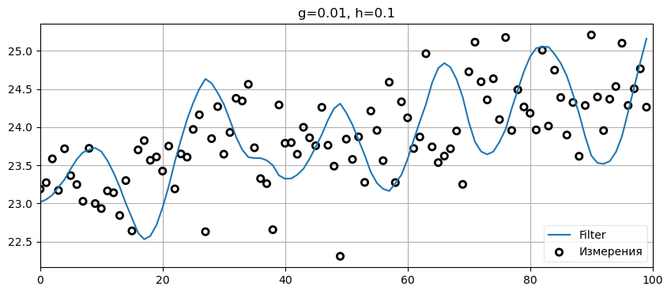

```python
zs = gen_train_data(pos=pos, vel=15., count=100)
data = g_h_filter(data=zs, x0=pos, dx=15., dt=1., g=0.01, h=0.1)
plot_g_h_results(zs/1000., data/1000., 'g=0.01, h=0.1')
```

Здесь положение меняется плавно благодаря небольшому значению g, но большое значение h делает фильтр очень чувствительным к измерениям. Это происходит потому, что в течение нескольких секунд быстро меняющееся измерение подразумевает очень большое изменение скорости, и большое значение h указывает фильтру быстро реагировать на эти изменения. Поезда не могут быстро менять скорость, поэтому фильтр плохо справляется с фильтрацией данных - фильтр меняет скорость быстрее, чем это может сделать поезд.

Наконец, давайте добавим некоторое ускорение поезду. Я не знаю, насколько быстро поезд может разогнаться на самом деле, но предположим, что он ускоряется со скоростью 0,2 ${м/сек^{2}}$.

```python
def gen_train_data_with_acc(pos, vel, count):
    zs = []
    for t in range(count):
        pos = compute_new_position(pos, vel)
        vel += 0.2
        zs.append(measure_position(pos))
    return np.asarray(zs)
```

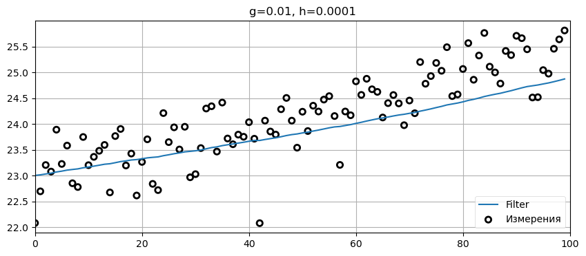

```python
zs = gen_train_data_with_acc(pos=pos, vel=15., count=100)
data = g_h_filter(data=zs, x0=pos, dx=15., dt=1., g=.01, h=0.0001)
plot_g_h_results(zs/1000., data/1000., 'g=0.01, h=0.0001')
```

Здесь мы видим, что фильтр больше не отслеживает движение поезда из-за ускорения. Мы можем поработать с $h$, чтобы он отслеживал лучше, за счет менее плавной отфильтрованной оценки.

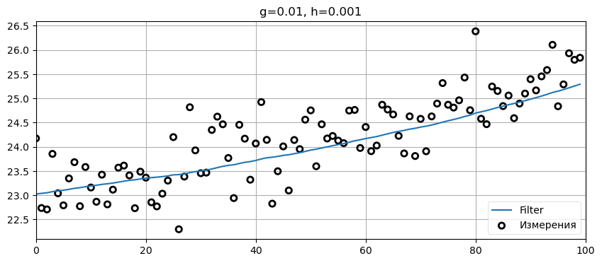

```python
zs = gen_train_data_with_acc(pos=pos, vel=15., count=100)
data = g_h_filter(data=zs, x0=pos, dx=15., dt=1., g=.01, h=0.001)
plot_g_h_results(zs/1000., data/1000., 'g=0.01, h=0.001')
```

Из этого примера следует извлечь два урока.

Во-первых, используйте параметр $h$, чтобы реагировать на изменения скорости, которые вы не моделируете. Но, что гораздо важнее, здесь есть компромисс между быстрым и точным реагированием на изменения в поведении и получением идеального результата, когда система находится в устойчивом состоянии, как у вас. Если поезд никогда не меняет скорость, мы бы сделали $h$ чрезвычайно малой, чтобы избежать чрезмерного влияния шума при измерении на отфильтрованную оценку. *Чем быстрее мы реагируем на измерения, тем больше на нас воздействует шум в датчиках.*

Мы могли бы продолжить, но наша цель состоит не столько в развитии теории фильтров g-h, сколько в том, чтобы получить представление о том, как сочетание измерений и прогнозов приводит к получению отфильтрованного решения. Существует множество литературы посвященной выбору $g$ и $h$ для таких задач, как эта, и существуют оптимальные способы их выбора для достижения различных целей. Как я объяснял ранее, при экспериментах с тестовыми данными, подобных этим, легко "обмануть" фильтр. В последующих главах мы узнаем, как фильтр Калмана решает эту проблему тем же базовым способом, но с помощью гораздо более сложной математики.

# Заключение

Я рекомендую вам поэкспериментировать с фильтром ${g-h}$, чтобы лучше понять, как он реагирует. Не потребуется слишком много попыток, чтобы понять, что специальные варианты значений для $g$ и $h$ работают не очень хорошо. Конкретный выбор может быть полезен в одной ситуации, но очень плохо - в другой. Даже если вы понимаете влияние значений $g$ и $h$, выбрать правильные значения может быть сложно. На самом деле, крайне маловероятно, что вы выберете оптимальные значения для $g$ и $h$, для решения любой задачи. Фильтры *разработаны*, а не выбраны *случайно*.

В некотором смысле я не хочу заканчивать эту главу здесь, поскольку мы можем многое сказать о выборе $g$ и $h$. Но фильтр g-h в таком виде не является целью этого курса. Разработка фильтра Калмана требует от вас указания ряда параметров - косвенно они действительно связаны с выбором $g$ и $h$, но вы никогда не будете ссылаться на них напрямую при разработке фильтров Калмана. Кроме того, $g$ и $h$ будут меняться на каждом временном шаге очень неочевидным образом.

Есть еще одна особенность этих фильтров, которую мы едва затронули, - Байесовская статистика. На данный момент мы оставим $ g$ и $ h$ позади, в значительной степени не изученными, и разработаем очень мощную форму вероятностных рассуждений о фильтрации. Что приведет нас к тому, что у нас появится тот же алгоритм фильтрации g-h, но на этот раз с формальной математической структурой, которая позволит нам создавать фильтры из нескольких датчиков и точно оценивать количество ошибок в нашем решении.